# Race/ethnicity, county income, and survival in adult acute lymhoblastic leukemia

## Cohort characteristics

```r
table1 <- df_model %>%
  group_by(race) %>%
  summarize(
    n = n(),
    deaths = sum(died),
    pct_dead = round(100 * mean(died), 1),
    pct_low_income = round(100 * mean(income_tier == "Low"), 1),
    pct_age_60plus = round(100 * mean(age_group %in% c("60-74", "75+")), 1),
    pct_male = round(100 * mean(Sex == "Male"), 1)
  )
write_csv(table1, "output/table1.csv")
knitr::kable(table1, caption = "Cohort characteristics by race/ethnicity")
```

Cohort characteristics by race/ethnicity

| race | n | deaths | pct_dead | pct_low_income | pct_age_60plus | pct_male |
| --- | --- | --- | --- | --- | --- | --- |
| Non-Hispanic White | 3934 | 2287 | 58.1 | 17.4 | 50.6 | 56.3 |
| Hispanic (All Races) | 2795 | 1393 | 49.8 | 7.3 | 21.3 | 55.9 |
| Non-Hispanic American Indian/Alaska Native | 84 | 48 | 57.1 | 34.5 | 22.6 | 53.6 |
| Non-Hispanic Asian or Pacific Islander | 714 | 324 | 45.4 | 2.4 | 35.0 | 53.5 |
| Non-Hispanic Black | 562 | 338 | 60.1 | 24.6 | 33.5 | 47.2 |

## Unadjusted survival

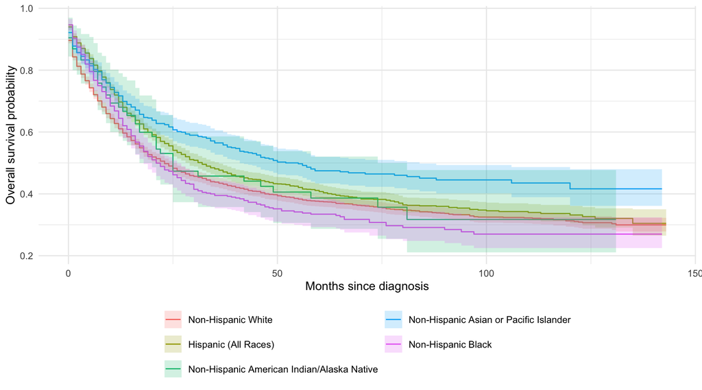

```r
km_race <- survfit2(Surv(survival_months, died) ~ race, data = df_model)

km_plot <- ggsurvfit(km_race) +
  add_confidence_interval() +
  labs(x = "Months since diagnosis", y = "Overall survival probability") +
  theme_minimal() +
  theme(legend.position = "bottom") +
  guides(color = guide_legend(nrow = 3), fill = guide_legend(nrow = 3))

ggsave("figures/km_race.png", km_plot, width = 9, height = 6, dpi = 300)
km_plot
```

## Adjusted survival, whole follow-up

```r
cox_overall <- coxph(Surv(survival_months, died) ~ race + income_tier + Sex + strata(age_group),
                     data = df_model)

tidy(cox_overall, exponentiate = TRUE, conf.int = TRUE) %>%
  mutate(across(c(estimate, conf.low, conf.high), ~ round(.x, 2)), p.value = format.pval(p.value, digits = 2, eps = 1e-4)) %>%
  select(term, hazard_ratio = estimate, conf.low, conf.high, p.value) %>%
  knitr::kable(caption = "Cox model over full follow-up (age-stratified)")
```

Cox model over full follow-up (age-stratified)

| term | hazard_ratio | conf.low | conf.high | p.value |
| --- | --- | --- | --- | --- |
| raceHispanic (All Races) | 1.20 | 1.12 | 1.29 | < 1e-04 |
| raceNon-Hispanic American Indian/Alaska Native | 1.29 | 0.97 | 1.72 | 0.08383 |
| raceNon-Hispanic Asian or Pacific Islander | 0.90 | 0.80 | 1.01 | 0.08249 |
| raceNon-Hispanic Black | 1.22 | 1.09 | 1.37 | 0.00062 |
| income_tierMiddle | 1.12 | 1.05 | 1.20 | 0.00103 |
| income_tierLow | 1.33 | 1.21 | 1.46 | < 1e-04 |
| SexMale | 1.09 | 1.02 | 1.16 | 0.00590 |

```r
cox.zph(cox_overall)
```

```
##              chisq df       p
## race        27.513  4 1.6e-05
## income_tier  7.046  2    0.03
## Sex          0.586  1    0.44
## GLOBAL      36.743  7 5.2e-06
```

The proportional-hazards test above indicates the effects change over follow-up, which motivates the time-split models.

## Adjusted survival by follow-up period

```r
df_split <- df_model %>%
  mutate(survival_months = survival_months + 0.5) %>%
  select(survival_months, died, race, income_tier, Sex, age_group) %>%
  survSplit(Surv(survival_months, died) ~ ., data = ., cut = 24, episode = "period")

cox_early <- coxph(Surv(tstart, survival_months, died) ~ race + income_tier + Sex + strata(age_group),
                   data = filter(df_split, period == 1))
cox_late <- coxph(Surv(tstart, survival_months, died) ~ race + income_tier + Sex + strata(age_group),
                  data = filter(df_split, period == 2))

hr_all <- bind_rows(
  tidy(cox_early, exponentiate = TRUE, conf.int = TRUE) %>% mutate(period = "0-24 months"),
  tidy(cox_late, exponentiate = TRUE, conf.int = TRUE) %>% mutate(period = "24+ months")
)

hr_all %>%
  mutate(across(c(estimate, conf.low, conf.high), ~ round(.x, 2)), p.value = format.pval(p.value, digits = 2, eps = 1e-4)) %>%
  select(period, term, hazard_ratio = estimate, conf.low, conf.high, p.value) %>%
  knitr::kable(caption = "Cox models by follow-up period (age-stratified)")
```

Cox models by follow-up period (age-stratified)

| period | term | hazard_ratio | conf.low | conf.high | p.value |
| --- | --- | --- | --- | --- | --- |
| 0-24 months | raceHispanic (All Races) | 1.14 | 1.05 | 1.23 | 0.00170 |
| 0-24 months | raceNon-Hispanic American Indian/Alaska Native | 1.23 | 0.88 | 1.70 | 0.22390 |
| 0-24 months | raceNon-Hispanic Asian or Pacific Islander | 0.88 | 0.77 | 1.01 | 0.07272 |
| 0-24 months | raceNon-Hispanic Black | 1.17 | 1.03 | 1.33 | 0.01666 |
| 0-24 months | income_tierMiddle | 1.15 | 1.06 | 1.24 | 0.00038 |
| 0-24 months | income_tierLow | 1.40 | 1.26 | 1.55 | < 1e-04 |
| 0-24 months | SexMale | 1.07 | 1.00 | 1.15 | 0.04263 |
| 24+ months | raceHispanic (All Races) | 1.52 | 1.30 | 1.78 | < 1e-04 |
| 24+ months | raceNon-Hispanic American Indian/Alaska Native | 1.56 | 0.86 | 2.86 | 0.14510 |
| 24+ months | raceNon-Hispanic Asian or Pacific Islander | 0.96 | 0.75 | 1.23 | 0.75826 |
| 24+ months | raceNon-Hispanic Black | 1.50 | 1.15 | 1.95 | 0.00266 |
| 24+ months | income_tierMiddle | 1.02 | 0.88 | 1.18 | 0.82103 |
| 24+ months | income_tierLow | 1.04 | 0.84 | 1.30 | 0.71561 |
| 24+ months | SexMale | 1.15 | 1.01 | 1.32 | 0.03876 |

```r
write_csv(hr_all, "output/hazard_ratios_by_period.csv")
```

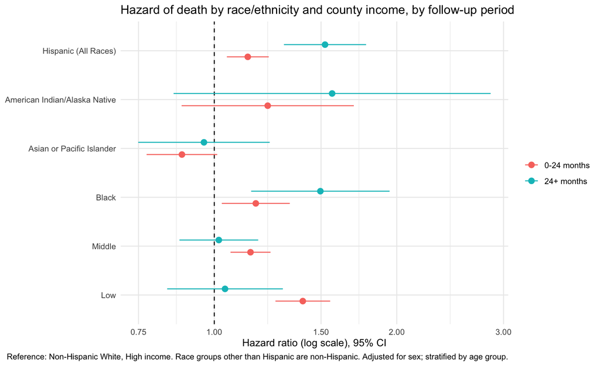

```r
hr_plot <- hr_all %>%
  filter(term != "SexMale") %>%
  mutate(term = str_remove_all(term, "^race|^income_tier|Non-Hispanic "),
         term = fct_rev(fct_inorder(term)))

forest <- ggplot(hr_plot, aes(x = estimate, y = term, color = period)) +
  geom_vline(xintercept = 1, linetype = "dashed") +
  geom_pointrange(aes(xmin = conf.low, xmax = conf.high), position = position_dodge(width = 0.5)) +
  scale_x_log10(breaks = c(0.75, 1, 1.5, 2, 3)) +
  labs(x = "Hazard ratio (log scale), 95% CI", y = NULL, color = NULL,
       title = "Hazard of death by race/ethnicity and county income, by follow-up period",
       caption = "Reference: Non-Hispanic White, High income. Race groups other than Hispanic are non-Hispanic. Adjusted for sex; stratified by age group.") +
  theme_minimal()

ggsave("figures/forest_plot.png", forest, width = 9, height = 5, dpi = 300)
forest
```

# Discussion

This analysis of adults with ALL determined that patients living in lower-income counties and being of Hispanic or Black race/ethnicity were associated with higher risk of death. After adjusting for county income, age and sex, the race/ethnicity differences remained, indicating that income-level alone does not attribute to the risk of death.

When looking at the unadjusted curve, Hispanic patients surived longer than non-Hispanic White paitents, but after adjustment, they show a higher risk. In this cohort, Hispanic patints were much younger, with only 21% being over the age of 60, while the non-Hispanic White cohort had 51% over the age of 60. Younger patinets, on average, live longer, which is likely the reaon why the unadjusted curve seemeed better, when comparing patinetes in teh same age group, that advantage was dropped. Both Hispanic and Black patinets saw an increase in the harazrd ratio 24 months after diagnosis, giong from aroudn 1.15 to 1.5. The Hispanic intervals don’t overlap, but the difference was not formally tested. Explanations, such as differneces in treatment access, and disease subtypes can’t be tested with this data.

Earlier SEER analysis of adult acute leukemia have also determined a higher risk of death amongst Hispanic and Black patients, specifically reporting hazard ratios around 1.45 in both groups (Patel et al., 2012). My estimates, around 1.2, could be smaller due to reasons such as: time period, age mix or adjustment. In childhood ALL, socioeconomic status has been reported to explain these gaps (Xu et al., 2021), but in this adult cohort, differences remained after adjusting for county income. One possible driver, differences in tumor biology (Xu et al., 2021), can not be examined with this data.

This study does have notebaly lmiations. One of the most prevalnt would be that socieocnonic facotrs wer etested through county-income, meaning low-income indivdal may be presnet in high-income counties and vice versa. The data alos lacks informaoitn regarding factors that heavily effect ALL and its outcome in patients, such as treatment, disease subtype, and insurance. The Alaska Native/American Indian cohort is too small to make firm judgements. Future work regarding treatment and indival-income levels could better test the differnece and fill gaps in understanding.

# Limitations

# References

- Patel MI, Ma Y, Mitchell BS, Rhoads KF. Understanding disparities in leukemia: a national study. Cancer Causes Control. 2012;23:1831-1837.
- Xu K, Feng Q, de Smith AJ. Disparities in acute lymphoblastic leukemia risk and survival across the lifespan in the United States of America. J Transl Genet Genom. 2021;5:218-239.